# Monitoramento Blend4

# PSI Base Geral Uniproponente

## Dia e Semana Raw

```
Período: 2026-09-28 00:00:00 → 2026-10-05 00:00:00
Volume total: 41,635
```

```
Semanas: 6 | Volume: 168,501
Período: 2026-08-30 00:00:00 → 2026-10-05 00:00:00
```

```
Target day: 2026-10-05
```

```
Target Week == 2026-09-27 (Última Semana Completa)
```

## PSI RAW BVS

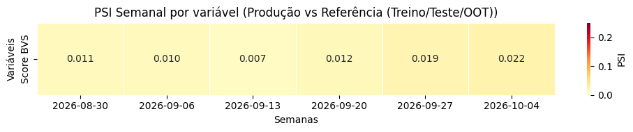

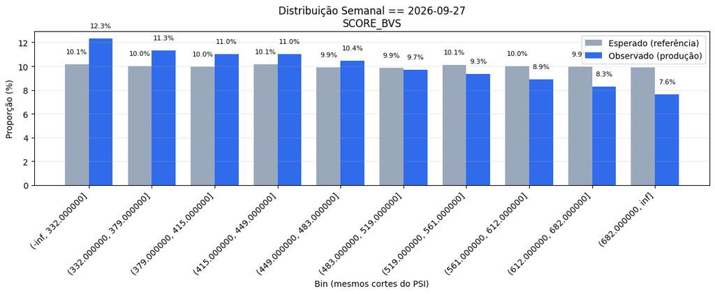

## PSI RAW Renda e Aluguel

Quantos % com predict_blend4 e renda 0?

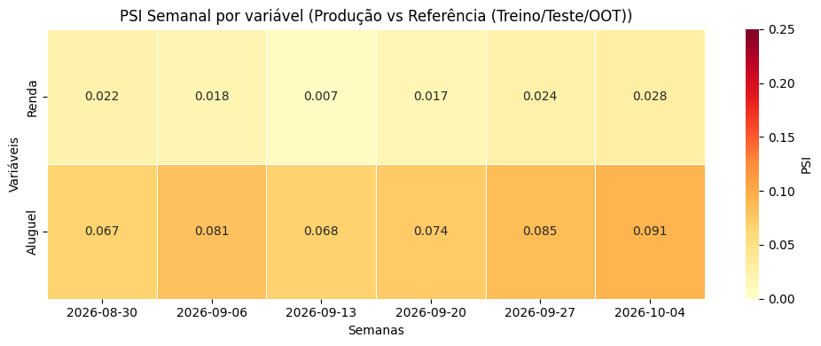

|  | income | rental_value |
| --- | --- | --- |
| count | 25965.000000 | 2.596500e+04 |
| mean | 6123.876256 | 9.762606e+03 |
| min | 685.000000 | 1.100000e+01 |
| 10% | 1438.500000 | 9.000000e+02 |
| 20% | 1712.500000 | 1.100000e+03 |
| 30% | 1986.500000 | 1.277966e+03 |
| 40% | 2329.000000 | 1.450000e+03 |
| 50% | 3014.000000 | 1.600000e+03 |
| 60% | 4041.500000 | 1.800000e+03 |
| 70% | 4863.500000 | 2.100000e+03 |
| 80% | 6507.500000 | 2.500000e+03 |
| 90% | 11165.500000 | 3.317000e+03 |
| max | 205500.000000 | 8.833062e+07 |
| std | 11903.460232 | 7.645475e+05 |

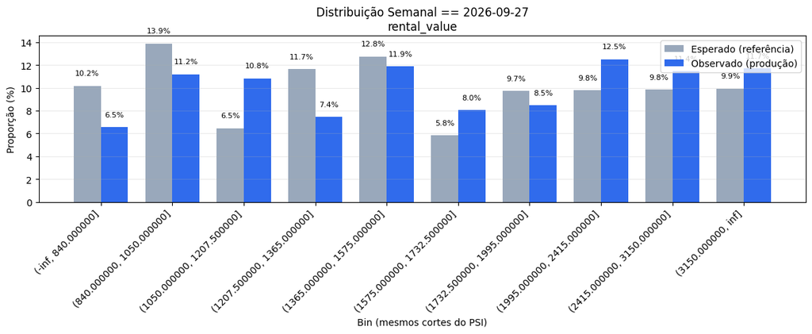

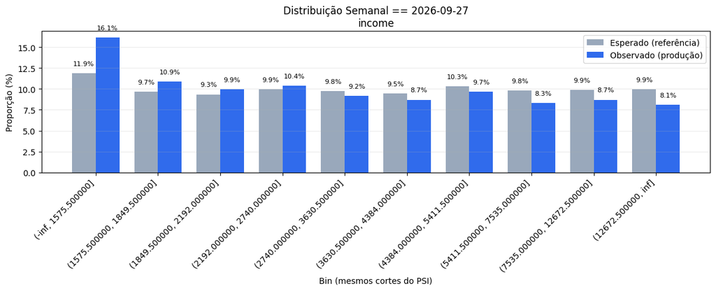

# Outras Análises

Análises Extras que servem para avaliar possíveis alterações que vemos na nossa base de leads.

## Comparação CR vs. Base Datalake PC Cidades / PC Imobiliárias

```
City safra (Blend3 < 01/09; Blend3+Blend4 >= 01/09): 243077
City freeze (>= 04/09): 112928
Agency (df_uniprop): 376492
city_safra rows: 241717
city_freeze rows: 112928
agency_safra rows: 31725
agency_freeze rows: 20411
```

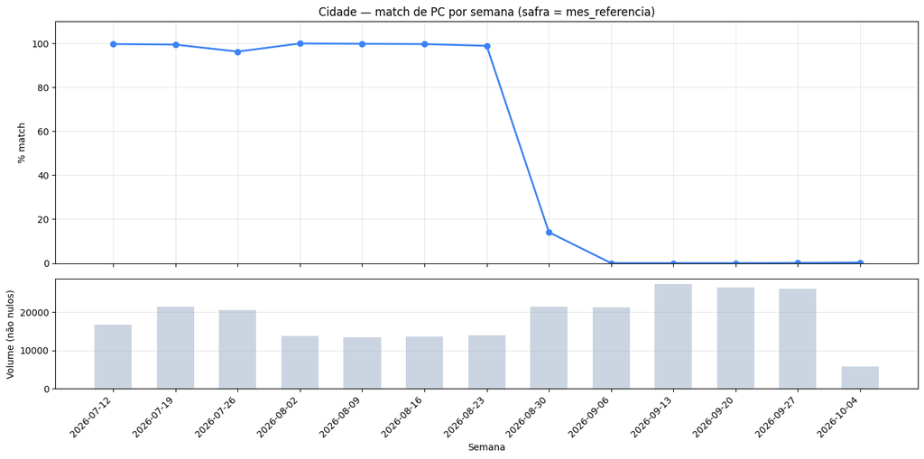

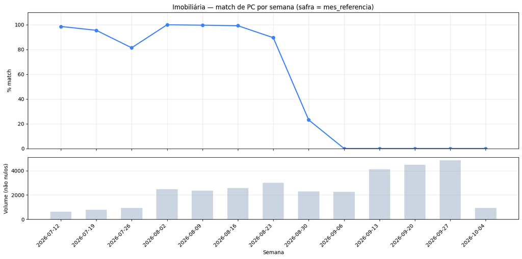

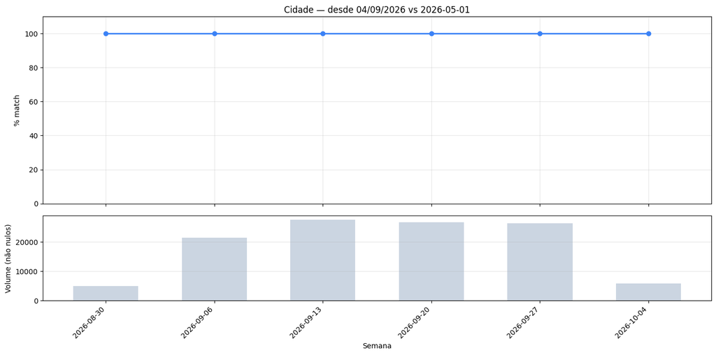

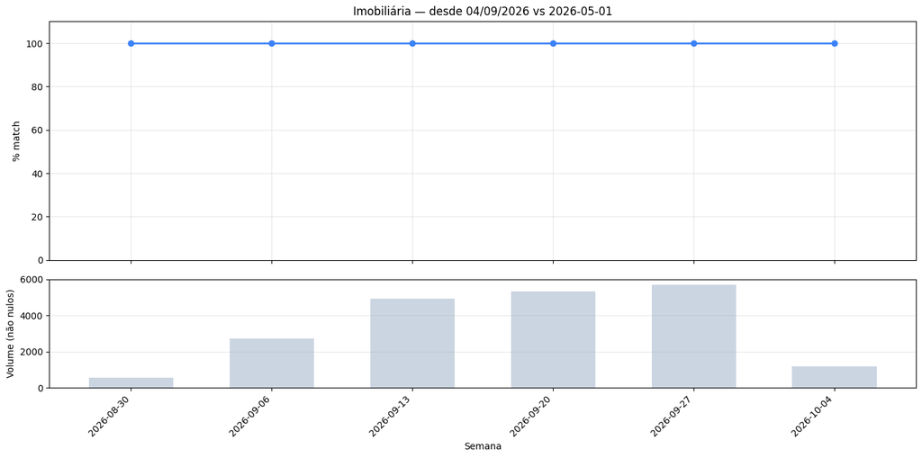

|  | contract_id | requested_at | message_decisao | year_week | week_start | safra_dt | id_key | value_prod | value_ref | diff | abs_diff |
| --- | --- | --- | --- | --- | --- | --- | --- | --- | --- | --- | --- |
| 200312 | 4387466 | 2026-07-17 | BLEND3_3 | 2026-07-12 | 2026-07-12 | 2026-07-01 | 4118204 | 0.086614 | 0.119403 | -0.032789 | 0.032789 |
| 114695 | 4372344 | 2026-07-14 | BLEND3_3 | 2026-07-12 | 2026-07-12 | 2026-07-01 | 3551702 | 0.031646 | 0.050000 | -0.018354 | 0.018354 |
| 128310 | 4373775 | 2026-07-15 | BLEND3_3 | 2026-07-12 | 2026-07-12 | 2026-07-01 | 3500105 | 0.047244 | 0.063830 | -0.016586 | 0.016586 |
| 200638 | 4379031 | 2026-07-15 | BLEND3_3 | 2026-07-12 | 2026-07-12 | 2026-07-01 | 3506508 | 0.083333 | 0.094955 | -0.011622 | 0.011622 |
| 223429 | 4387686 | 2026-07-17 | BLEND3_3 | 2026-07-12 | 2026-07-12 | 2026-07-01 | 3506508 | 0.083333 | 0.094955 | -0.011622 | 0.011622 |
| ... | ... | ... | ... | ... | ... | ... | ... | ... | ... | ... | ... |
| 210393 | 4759125 | 2026-10-05 | BLEND_4 | 2026-10-04 | 2026-10-04 | 2026-10-01 | 3524402 | 0.094320 | 0.094421 | -0.000100 | 0.000100 |
| 30359 | 4759134 | 2026-10-05 | BLEND3_3 | 2026-10-04 | 2026-10-04 | 2026-10-01 | 3524402 | 0.094320 | 0.094421 | -0.000100 | 0.000100 |
| 87670 | 4759424 | 2026-10-05 | BLEND_4 | 2026-10-04 | 2026-10-04 | 2026-10-01 | 3524402 | 0.094320 | 0.094421 | -0.000100 | 0.000100 |
| 224865 | 4759566 | 2026-10-05 | BLEND3_3 | 2026-10-04 | 2026-10-04 | 2026-10-01 | 3524402 | 0.094320 | 0.094421 | -0.000100 | 0.000100 |
| 62122 | 4759680 | 2026-10-05 | BLEND_4 | 2026-10-04 | 2026-10-04 | 2026-10-01 | 3524402 | 0.094320 | 0.094421 | -0.000100 | 0.000100 |

126348 rows × 11 columns

|  | contract_id | requested_at | message_decisao | year_week | week_start | safra_dt | id_key | value_prod | value_ref | diff | abs_diff |
| --- | --- | --- | --- | --- | --- | --- | --- | --- | --- | --- | --- |
| 14850 | 4384946 | 2026-07-17 | BLEND_4 | 2026-07-12 | 2026-07-12 | 2026-07-01 | 33067 | 0.154867 | 0.136364 | 0.018504 | 0.018504 |
| 19706 | 4387276 | 2026-07-17 | BLEND_4 | 2026-07-12 | 2026-07-12 | 2026-07-01 | 13380 | 0.342105 | 0.354839 | -0.012733 | 0.012733 |
| 3322 | 4390907 | 2026-07-18 | BLEND_4 | 2026-07-12 | 2026-07-12 | 2026-07-01 | 215 | 0.212329 | 0.200000 | 0.012329 | 0.012329 |
| 14462 | 4388655 | 2026-07-17 | BLEND_4 | 2026-07-12 | 2026-07-12 | 2026-07-01 | 2164 | 0.246795 | 0.235465 | 0.011330 | 0.011330 |
| 21628 | 4380092 | 2026-07-16 | BLEND_4 | 2026-07-12 | 2026-07-12 | 2026-07-01 | 389 | 0.078292 | 0.071661 | 0.006631 | 0.006631 |
| ... | ... | ... | ... | ... | ... | ... | ... | ... | ... | ... | ... |
| 18051 | 4755159 | 2026-10-05 | BLEND_4 | 2026-10-04 | 2026-10-04 | 2026-10-01 | 3037 | 0.165919 | 0.164384 | 0.001536 | 0.001536 |
| 5854 | 4757509 | 2026-10-05 | BLEND_4 | 2026-10-04 | 2026-10-04 | 2026-10-01 | 3037 | 0.165919 | 0.164384 | 0.001536 | 0.001536 |
| 10160 | 4757675 | 2026-10-05 | BLEND_4 | 2026-10-04 | 2026-10-04 | 2026-10-01 | 3037 | 0.165919 | 0.164384 | 0.001536 | 0.001536 |
| 2575 | 4758823 | 2026-10-05 | BLEND_4 | 2026-10-04 | 2026-10-04 | 2026-10-01 | 3037 | 0.165919 | 0.164384 | 0.001536 | 0.001536 |
| 3633 | 4758217 | 2026-10-05 | BLEND_4 | 2026-10-04 | 2026-10-04 | 2026-10-01 | 9418 | 0.062937 | 0.064000 | -0.001063 | 0.001063 |

18993 rows × 11 columns

|  | contract_id | requested_at | message_decisao | year_week | week_start | safra_dt | id_key | value_prod | value_ref | diff | abs_diff |
| --- | --- | --- | --- | --- | --- | --- | --- | --- | --- | --- | --- |

|  | contract_id | requested_at | message_decisao | year_week | week_start | safra_dt | id_key | value_prod | value_ref | diff | abs_diff |
| --- | --- | --- | --- | --- | --- | --- | --- | --- | --- | --- | --- |

## Cidades/Imobiliária que deveriam estar sendo utilizadas na PC Cidades / PC Imobiliária

Cidades e imobiliárias que chegaram com a variável de PC nula, embora o ID exista em `df_city` / `df_agency` — nesses casos o PC deveria ter sido preenchido.

```
Cidade — contratos com PC nulo e ID no datalake: 17198 (210 cidades)
Imobiliária — contratos com PC nulo e ID no datalake: 17617 (186 imobiliárias)
```

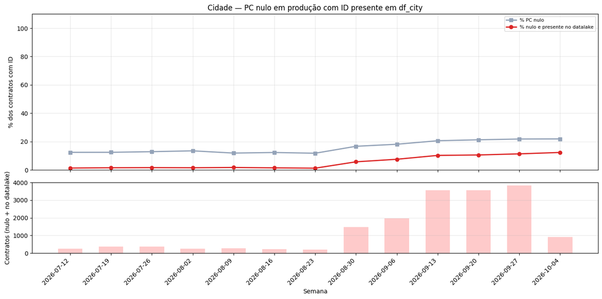

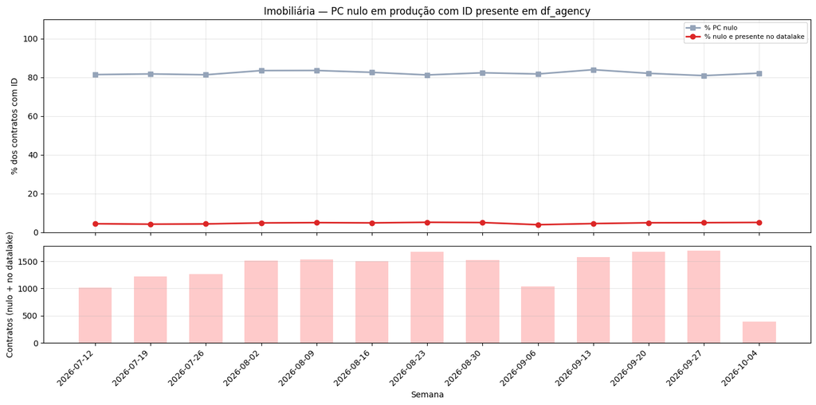

```
Resumo semanal — cidade
```

|  | Semana | Volume com ID | PC nulo | Nulo e no datalake | Nulo no lookup da safra/freeze | % PC nulo | % nulo e no datalake |
| --- | --- | --- | --- | --- | --- | --- | --- |
| 0 | 2026-07-12 | 19016 | 2354 | 244 | 0 | 12.38 | 1.28 |
| 1 | 2026-07-19 | 24359 | 3022 | 367 | 0 | 12.41 | 1.51 |
| 2 | 2026-07-26 | 23654 | 3039 | 377 | 4 | 12.85 | 1.59 |
| 3 | 2026-08-02 | 15856 | 2132 | 239 | 0 | 13.45 | 1.51 |
| 4 | 2026-08-09 | 15312 | 1816 | 261 | 0 | 11.86 | 1.7 |
| 5 | 2026-08-16 | 15525 | 1905 | 221 | 0 | 12.27 | 1.42 |
| 6 | 2026-08-23 | 15872 | 1865 | 191 | 2 | 11.75 | 1.2 |
| 7 | 2026-08-30 | 25869 | 4307 | 1473 | 1126 | 16.65 | 5.69 |
| 8 | 2026-09-06 | 26262 | 4752 | 1968 | 1566 | 18.09 | 7.49 |
| 9 | 2026-09-13 | 34767 | 7152 | 3552 | 3154 | 20.57 | 10.22 |
| 10 | 2026-09-20 | 33862 | 7190 | 3565 | 3067 | 21.23 | 10.53 |
| 11 | 2026-09-27 | 33777 | 7358 | 3821 | 3367 | 21.78 | 11.31 |
| 12 | 2026-10-04 | 7471 | 1633 | 919 | 803 | 21.86 | 12.3 |

```
Resumo semanal — imobiliária
```

|  | Semana | Volume com ID | PC nulo | Nulo e no datalake | Nulo no lookup da safra/freeze | % PC nulo | % nulo e no datalake |
| --- | --- | --- | --- | --- | --- | --- | --- |
| 0 | 2026-07-12 | 23208 | 18897 | 1020 | 76 | 81.42 | 4.4 |
| 1 | 2026-07-19 | 29330 | 23984 | 1219 | 93 | 81.77 | 4.16 |
| 2 | 2026-07-26 | 29537 | 24025 | 1268 | 128 | 81.34 | 4.29 |
| 3 | 2026-08-02 | 31457 | 26266 | 1512 | 264 | 83.5 | 4.81 |
| 4 | 2026-08-09 | 30777 | 25716 | 1529 | 283 | 83.56 | 4.97 |
| 5 | 2026-08-16 | 31148 | 25724 | 1505 | 305 | 82.59 | 4.83 |
| 6 | 2026-08-23 | 32534 | 26432 | 1673 | 340 | 81.24 | 5.14 |
| 7 | 2026-08-30 | 30550 | 25162 | 1528 | 383 | 82.36 | 5.0 |
| 8 | 2026-09-06 | 26559 | 21712 | 1033 | 325 | 81.75 | 3.89 |
| 9 | 2026-09-13 | 35218 | 29567 | 1575 | 604 | 83.95 | 4.47 |
| 10 | 2026-09-20 | 34244 | 28107 | 1674 | 672 | 82.08 | 4.89 |
| 11 | 2026-09-27 | 34325 | 27770 | 1696 | 803 | 80.9 | 4.94 |
| 12 | 2026-10-04 | 7605 | 6249 | 385 | 160 | 82.17 | 5.06 |

```
Cidades com PC nulo apesar de existirem em df_city
```

|  | id_cidade_ibge | n_contratos | n_semanas | pc_datalake | pc_safra | n_na_safra | modelos | pct_na_safra |
| --- | --- | --- | --- | --- | --- | --- | --- | --- |
| 102 | 3550308 | 543 | 6 | 0.092869 | 0.096899 | 543 | BLEND_4 | 100.0 |
| 81 | 3530607 | 510 | 9 | 0.074766 | 0.074766 | 331 | BLEND3_3, BLEND_4 | 64.901961 |
| 180 | 4313375 | 441 | 13 | 0.235933 | NaN | 0 | BLEND3_3, BLEND_4 | 0.0 |
| 147 | 4208203 | 408 | 6 | 0.136032 | 0.134762 | 408 | BLEND_4 | 100.0 |
| 88 | 3538709 | 368 | 6 | 0.095408 | 0.107746 | 368 | BLEND_4 | 100.0 |
| 123 | 4113700 | 363 | 6 | 0.111653 | 0.118656 | 363 | BLEND_4 | 100.0 |
| 76 | 3526902 | 356 | 6 | 0.132604 | 0.134156 | 356 | BLEND_4 | 100.0 |
| 54 | 3506003 | 333 | 6 | 0.119205 | 0.129154 | 333 | BLEND_4 | 100.0 |
| 185 | 4314902 | 308 | 6 | 0.091747 | 0.085416 | 308 | BLEND_4 | 100.0 |
| 75 | 3526803 | 302 | 11 | 0.122642 | NaN | 0 | BLEND3_3, BLEND_4 | 0.0 |
| 188 | 4316907 | 278 | 6 | 0.122293 | 0.113166 | 278 | BLEND_4 | 100.0 |
| 176 | 4309209 | 277 | 6 | 0.171472 | 0.184211 | 277 | BLEND_4 | 100.0 |
| 108 | 3557006 | 250 | 13 | 0.116071 | NaN | 0 | BLEND3_3, BLEND_4 | 0.0 |
| 83 | 3533403 | 245 | 13 | 0.049020 | NaN | 0 | BLEND3_3, BLEND_4 | 0.0 |
| 121 | 4109807 | 238 | 13 | 0.043103 | NaN | 0 | BLEND3_3, BLEND_4 | 0.0 |
| 205 | 5208707 | 235 | 6 | 0.165885 | 0.184821 | 235 | BLEND_4 | 100.0 |
| 73 | 3525300 | 218 | 6 | 0.108342 | 0.145349 | 218 | BLEND_4 | 100.0 |
| 40 | 3304201 | 207 | 13 | 0.029126 | NaN | 0 | BLEND3_3, BLEND_4 | 0.0 |
| 137 | 4202404 | 203 | 6 | 0.087471 | 0.097267 | 203 | BLEND_4 | 100.0 |
| 91 | 3543402 | 198 | 6 | 0.124486 | 0.126154 | 198 | BLEND_4 | 100.0 |
| 72 | 3524402 | 196 | 6 | 0.094421 | 0.087958 | 196 | BLEND_4 | 100.0 |
| 98 | 3548906 | 193 | 6 | 0.122203 | 0.112409 | 193 | BLEND_4 | 100.0 |
| 169 | 4304606 | 180 | 6 | 0.098206 | 0.098410 | 180 | BLEND_4 | 100.0 |
| 117 | 4106902 | 178 | 6 | 0.081857 | 0.079022 | 178 | BLEND_4 | 100.0 |
| 100 | 3549805 | 175 | 6 | 0.116364 | 0.116364 | 175 | BLEND_4 | 100.0 |
| 183 | 4314407 | 172 | 6 | 0.161826 | 0.176596 | 172 | BLEND_4 | 100.0 |
| 47 | 3501905 | 171 | 13 | 0.040323 | NaN | 0 | BLEND3_3, BLEND_4 | 0.0 |
| 2 | 2403251 | 170 | 6 | 0.096154 | NaN | 0 | BLEND3_3, BLEND_4 | 0.0 |
| 16 | 3122306 | 170 | 6 | 0.167712 | 0.190813 | 170 | BLEND_4 | 100.0 |
| 55 | 3506508 | 164 | 6 | 0.106017 | 0.104294 | 164 | BLEND_4 | 100.0 |
| 148 | 4208302 | 161 | 6 | 0.133152 | 0.131965 | 161 | BLEND_4 | 100.0 |
| 171 | 4305108 | 159 | 6 | 0.106280 | 0.117685 | 159 | BLEND_4 | 100.0 |
| 203 | 5107909 | 156 | 7 | 0.037037 | 0.046729 | 25 | BLEND3_3, BLEND_4 | 16.025641 |
| 139 | 4203204 | 155 | 6 | 0.159686 | 0.152589 | 155 | BLEND_4 | 100.0 |
| 49 | 3502804 | 154 | 6 | 0.096154 | 0.093960 | 154 | BLEND_4 | 100.0 |
| 29 | 3170206 | 152 | 6 | 0.150333 | 0.178105 | 152 | BLEND_4 | 100.0 |
| 41 | 3304557 | 149 | 6 | 0.066284 | 0.063573 | 149 | BLEND_4 | 100.0 |
| 129 | 4119905 | 142 | 6 | 0.108225 | 0.109635 | 142 | BLEND_4 | 100.0 |
| 6 | 2704302 | 141 | 13 | 0.134396 | NaN | 0 | BLEND3_3, BLEND_4 | 0.0 |
| 165 | 4303004 | 134 | 6 | 0.072727 | 0.092593 | 134 | BLEND3_3, BLEND_4 | 100.0 |

```
Imobiliárias com PC nulo apesar de existirem em df_agency
```

|  | agency_id | n_contratos | n_semanas | pc_datalake | pc_safra | n_na_safra | modelos | pct_na_safra |
| --- | --- | --- | --- | --- | --- | --- | --- | --- |
| 98 | 4881 | 1110 | 13 | 0.047619 | NaN | 0 | BLEND3_3, BLEND_4, BVS_CUSTOM, BVS_CUSTOM_V2, ... | 0.0 |
| 30 | 910 | 850 | 13 | 0.210884 | NaN | 0 | BLEND3_3, BLEND_4, BVS_CUSTOM_V2, HFT1, HVA4 | 0.0 |
| 41 | 1156 | 737 | 13 | 0.157025 | NaN | 0 | BLEND3_3, BLEND_4, BVS_CUSTOM_V2, HFT1, HVA4 | 0.0 |
| 157 | 17378 | 529 | 13 | 0.198347 | NaN | 0 | BLEND3_3, BLEND_4, BVS_CUSTOM, BVS_CUSTOM_V2, ... | 0.0 |
| 139 | 11985 | 486 | 13 | 0.134146 | NaN | 0 | BLEND3_3, BLEND_4, BVS_CUSTOM_V2, HFT1, HVA4 | 0.0 |
| 168 | 25380 | 403 | 13 | 0.129927 | 0.108911 | 182 | BLEND3_3, BLEND_4, BVS_CUSTOM, BVS_CUSTOM_V2, ... | 45.16129 |
| 170 | 25753 | 382 | 12 | 0.134921 | NaN | 0 | BLEND3_3, BLEND_4, BVS_CUSTOM_V2, HVA4 | 0.0 |
| 148 | 13335 | 344 | 13 | 0.100840 | NaN | 0 | BLEND3_3, BLEND_4, BVS_CUSTOM_V2 | 0.0 |
| 118 | 7309 | 341 | 13 | 0.168317 | NaN | 0 | BLEND3_3, BLEND_4, BVS_CUSTOM_V2, HFT1, HVA4 | 0.0 |
| 29 | 902 | 319 | 12 | 0.167635 | NaN | 0 | BLEND3_3, BLEND_4, BVS_CUSTOM_V2, HVA4 | 0.0 |
| 7 | 315 | 317 | 13 | 0.088995 | 0.079208 | 127 | BLEND3_3, BLEND_4, BVS_CUSTOM_V2, HVA4 | 40.063091 |
| 67 | 2648 | 310 | 11 | 0.043561 | NaN | 0 | BLEND3_3, BLEND_4, HVA4 | 0.0 |
| 49 | 1607 | 303 | 13 | 0.094017 | NaN | 0 | BLEND3_3, BLEND_4, HFT1, HVA4 | 0.0 |
| 71 | 2687 | 284 | 13 | 0.123580 | 0.140379 | 284 | BLEND_4 | 100.0 |
| 82 | 3383 | 276 | 13 | 0.086207 | 0.067961 | 19 | BLEND3_3, BLEND_4, BVS_CUSTOM_V2 | 6.884058 |
| 155 | 16400 | 271 | 13 | 0.045872 | NaN | 0 | BLEND3_3, BLEND_4, BVS_CUSTOM, BVS_CUSTOM_V2 | 0.0 |
| 173 | 27359 | 270 | 13 | 0.069307 | 0.069307 | 96 | BLEND3_3, BLEND_4 | 35.555556 |
| 40 | 1145 | 263 | 13 | 0.166667 | NaN | 0 | BLEND3_3, BLEND_4, BVS_CUSTOM_V2, HVA4 | 0.0 |
| 86 | 3552 | 257 | 11 | 0.105570 | NaN | 0 | BLEND3_3, BLEND_4, BVS_CUSTOM_V2, HVA4 | 0.0 |
| 176 | 34329 | 252 | 13 | 0.089109 | NaN | 0 | BLEND3_3, BLEND_4, HVA4 | 0.0 |
| 6 | 314 | 236 | 11 | 0.225490 | 0.225490 | 1 | BLEND3_3, BLEND_4, BVS_CUSTOM_V2 | 0.423729 |
| 18 | 620 | 235 | 13 | 0.083333 | NaN | 0 | BLEND3_3, BLEND_4, HVA4 | 0.0 |
| 182 | 44081 | 230 | 13 | 0.441667 | NaN | 0 | BLEND3_3, BLEND_4, BVS_CUSTOM_V2 | 0.0 |
| 72 | 2783 | 215 | 13 | 0.176000 | NaN | 0 | BLEND3_3, BLEND_4, BVS_CUSTOM, BVS_CUSTOM_V2 | 0.0 |
| 167 | 25347 | 206 | 10 | 0.107438 | NaN | 0 | BLEND3_3, BLEND_4, HFT1, HVA4 | 0.0 |
| 103 | 5191 | 203 | 13 | 0.076923 | NaN | 0 | BLEND3_3, BLEND_4, BVS_CUSTOM_V2, HFT1, HVA4 | 0.0 |
| 142 | 12299 | 199 | 13 | 0.099010 | NaN | 0 | BLEND3_3, BLEND_4, BVS_CUSTOM_V2, HVA4 | 0.0 |
| 179 | 35407 | 186 | 10 | 0.166032 | NaN | 0 | BLEND3_3, BLEND_4, HVA4 | 0.0 |
| 60 | 2124 | 183 | 12 | 0.178862 | 0.178862 | 111 | BLEND3_3, BLEND_4, HFT1 | 60.655738 |
| 94 | 4438 | 183 | 13 | 0.112247 | 0.122642 | 91 | BLEND3_3, BLEND_4, BVS_CUSTOM_V2 | 49.726776 |
| 97 | 4549 | 179 | 13 | 0.138614 | 0.146766 | 179 | BLEND_4 | 100.0 |
| 21 | 649 | 166 | 13 | 0.123967 | NaN | 0 | BLEND3_3, BLEND_4, HVA4 | 0.0 |
| 106 | 5531 | 162 | 10 | 0.143223 | 0.148515 | 2 | BLEND3_3, BLEND_4, BVS_CUSTOM_V2, HVA4 | 1.234568 |
| 185 | 50714 | 156 | 11 | 0.065543 | 0.057692 | 15 | BLEND3_3, BLEND_4, BVS_CUSTOM_V2 | 9.615385 |
| 47 | 1416 | 147 | 13 | 0.125000 | NaN | 0 | BLEND3_3, BLEND_4, BVS_CUSTOM_V2, HVA4 | 0.0 |
| 166 | 23239 | 146 | 13 | 0.093137 | NaN | 0 | BLEND3_3, BLEND_4, BVS_CUSTOM_V2, HVA4 | 0.0 |
| 3 | 215 | 145 | 13 | 0.178914 | 0.214789 | 145 | BLEND_4 | 100.0 |
| 75 | 2874 | 140 | 10 | 0.356164 | NaN | 0 | BLEND3_3, BLEND_4, HVA4 | 0.0 |
| 126 | 9118 | 140 | 12 | 0.305970 | 0.291667 | 140 | BLEND_4 | 100.0 |
| 143 | 12326 | 137 | 11 | 0.092215 | 0.090090 | 100 | BLEND3_3, BLEND_4 | 72.992701 |

## Semana 26-07-2026

```
CIDADE
========================================================================================
CIDADE | semana 2026-07-12 | n=16662 | match=99.74%

-- por dia --
               n  n_ok    pct
dia
2026-07-14  4304  4296  99.81
2026-07-15  4395  4387  99.82
2026-07-16  3484  3469  99.57
2026-07-17  3667  3658  99.75
2026-07-18   812   809  99.63

-- por safra --
               n   n_ok    pct
safra_mes
2026-07    16662  16619  99.74

-- por modelo --
                     n   n_ok    pct
message_decisao
BLEND3_3         16662  16619  99.74

-- mismatches: 43 --

por dia (só erro)
dia
2026-07-14     8
2026-07-15     8
2026-07-16    15
2026-07-17     9
2026-07-18     3

top 15 entidades
         n_erro  value_prod  value_ref  abs_diff
id_key
4314902       3    0.091747   0.087567  0.004180
3502804       3    0.083947   0.083700  0.000247
3550308       3    0.094720   0.089384  0.005336
4208906       2    0.082090   0.072189  0.009900
3118601       2    0.123391   0.123858  0.000467
3506508       2    0.083333   0.094955  0.011622
4205407       2    0.082773   0.080854  0.001919
4204202       1    0.135667   0.140461  0.004794
4106902       1    0.073999   0.076923  0.002924
4107652       1    0.100386   0.101961  0.001575
4118204       1    0.086614   0.119403  0.032789
3106200       1    0.076433   0.076716  0.000283
4204608       1    0.123431   0.122554  0.000877
4209102       1    0.058127   0.056856  0.001271
4218004       1    0.078873   0.068120  0.010753

amostra de erros
```

|  | contract_id | dia | requested_at | message_decisao | safra_mes | id_key | value_prod | value_ref | abs_diff |
| --- | --- | --- | --- | --- | --- | --- | --- | --- | --- |
| 199832 | 4371768 | 2026-07-14 | 2026-07-14 | BLEND3_3 | 2026-07 | 3127701 | 0.145482 | 0.146341 | 0.000859 |
| 201614 | 4369444 | 2026-07-14 | 2026-07-14 | BLEND3_3 | 2026-07 | 3138203 | 0.104938 | 0.096970 | 0.007969 |
| 177463 | 4371073 | 2026-07-14 | 2026-07-14 | BLEND3_3 | 2026-07 | 3502804 | 0.083947 | 0.083700 | 0.000247 |
| 4112 | 4369752 | 2026-07-14 | 2026-07-14 | BLEND3_3 | 2026-07 | 3518800 | 0.132558 | 0.135476 | 0.002918 |
| 114695 | 4372344 | 2026-07-14 | 2026-07-14 | BLEND3_3 | 2026-07 | 3551702 | 0.031646 | 0.050000 | 0.018354 |
| 200094 | 4372621 | 2026-07-14 | 2026-07-14 | BLEND3_3 | 2026-07 | 4106902 | 0.073999 | 0.076923 | 0.002924 |
| 176446 | 4368705 | 2026-07-14 | 2026-07-14 | BLEND3_3 | 2026-07 | 4107652 | 0.100386 | 0.101961 | 0.001575 |
| 58905 | 4373067 | 2026-07-14 | 2026-07-14 | BLEND3_3 | 2026-07 | 4204202 | 0.135667 | 0.140461 | 0.004794 |
| 149520 | 4374870 | 2026-07-15 | 2026-07-15 | BLEND3_3 | 2026-07 | 3118601 | 0.123391 | 0.123858 | 0.000467 |
| 149664 | 4377406 | 2026-07-15 | 2026-07-15 | BLEND3_3 | 2026-07 | 3170206 | 0.155369 | 0.147808 | 0.007562 |
| 128310 | 4373775 | 2026-07-15 | 2026-07-15 | BLEND3_3 | 2026-07 | 3500105 | 0.047244 | 0.063830 | 0.016586 |
| 58858 | 4379205 | 2026-07-15 | 2026-07-15 | BLEND3_3 | 2026-07 | 3502804 | 0.083947 | 0.083700 | 0.000247 |
| 157105 | 4378354 | 2026-07-15 | 2026-07-15 | BLEND3_3 | 2026-07 | 3502804 | 0.083947 | 0.083700 | 0.000247 |
| 200638 | 4379031 | 2026-07-15 | 2026-07-15 | BLEND3_3 | 2026-07 | 3506508 | 0.083333 | 0.094955 | 0.011622 |
| 125090 | 4377911 | 2026-07-15 | 2026-07-15 | BLEND3_3 | 2026-07 | 3530508 | 0.079268 | 0.087719 | 0.008451 |
| 128817 | 4377422 | 2026-07-15 | 2026-07-15 | BLEND3_3 | 2026-07 | 4307906 | 0.062257 | 0.057143 | 0.005114 |
| 177525 | 4379973 | 2026-07-16 | 2026-07-16 | BLEND3_3 | 2026-07 | 3118601 | 0.123391 | 0.123858 | 0.000467 |
| 15815 | 4383820 | 2026-07-16 | 2026-07-16 | BLEND3_3 | 2026-07 | 3501608 | 0.111111 | 0.102599 | 0.008512 |
| 135577 | 4379809 | 2026-07-16 | 2026-07-16 | BLEND3_3 | 2026-07 | 3525300 | 0.118863 | 0.108342 | 0.010521 |
| 88744 | 4380530 | 2026-07-16 | 2026-07-16 | BLEND3_3 | 2026-07 | 3526902 | 0.130775 | 0.119879 | 0.010897 |
| 236210 | 4362202 | 2026-07-16 | 2026-07-16 | BLEND3_3 | 2026-07 | 3538709 | 0.104636 | 0.106942 | 0.002306 |
| 205236 | 4381269 | 2026-07-16 | 2026-07-16 | BLEND3_3 | 2026-07 | 3543402 | 0.124486 | 0.120879 | 0.003606 |
| 86983 | 4381475 | 2026-07-16 | 2026-07-16 | BLEND3_3 | 2026-07 | 3549805 | 0.113662 | 0.104510 | 0.009152 |
| 98105 | 4383842 | 2026-07-16 | 2026-07-16 | BLEND3_3 | 2026-07 | 3550308 | 0.094720 | 0.089384 | 0.005336 |
| 173949 | 4384062 | 2026-07-16 | 2026-07-16 | BLEND3_3 | 2026-07 | 3550308 | 0.094720 | 0.089384 | 0.005336 |
| 125745 | 4379853 | 2026-07-16 | 2026-07-16 | BLEND3_3 | 2026-07 | 4204608 | 0.123431 | 0.122554 | 0.000877 |
| 162473 | 4379774 | 2026-07-16 | 2026-07-16 | BLEND3_3 | 2026-07 | 4205407 | 0.082773 | 0.080854 | 0.001919 |
| 225877 | 4384406 | 2026-07-16 | 2026-07-16 | BLEND3_3 | 2026-07 | 4208906 | 0.082090 | 0.072189 | 0.009900 |
| 56725 | 4381998 | 2026-07-16 | 2026-07-16 | BLEND3_3 | 2026-07 | 4218004 | 0.078873 | 0.068120 | 0.010753 |
| 235700 | 4383385 | 2026-07-16 | 2026-07-16 | BLEND3_3 | 2026-07 | 4304606 | 0.092338 | 0.084211 | 0.008127 |

```
========================================================================================
CIDADE | semana 2026-07-19 | n=21337 | match=99.48%

-- por dia --
               n  n_ok     pct
dia
2026-07-19   149   149  100.00
2026-07-20  4410  4393   99.61
2026-07-21  4262  4241   99.51
2026-07-22  4182  4169   99.69
2026-07-23  4073  4040   99.19
2026-07-24  3518  3494   99.32
2026-07-25   743   741   99.73

-- por safra --
               n   n_ok    pct
safra_mes
2026-07    21337  21227  99.48

-- por modelo --
                     n   n_ok    pct
message_decisao
BLEND3_3         21337  21227  99.48

-- mismatches: 110 --

por dia (só erro)
dia
2026-07-20    17
2026-07-21    21
2026-07-22    13
2026-07-23    33
2026-07-24    24
2026-07-25     2

top 15 entidades
         n_erro  value_prod  value_ref  abs_diff
id_key
3519071       8    0.087719   0.089347  0.001628
4113700       7    0.113262   0.107708  0.005553
4305108       4    0.111354   0.100719  0.010634
3304557       4    0.066284   0.058575  0.007709
3502804       3    0.083947   0.083700  0.000247
3525300       3    0.118863   0.108342  0.010521
3550308       3    0.094720   0.089384  0.005336
3509502       3    0.071130   0.076923  0.005793
4208906       3    0.082090   0.072189  0.009900
4304606       3    0.092338   0.084211  0.008127
4202404       3    0.091414   0.087038  0.004376
4106902       2    0.073999   0.076923  0.002924
4311403       2    0.131148   0.142132  0.010984
4115200       2    0.086386   0.081738  0.004649
4201406       2    0.112613   0.138889  0.026276

amostra de erros
```

|  | contract_id | dia | requested_at | message_decisao | safra_mes | id_key | value_prod | value_ref | abs_diff |
| --- | --- | --- | --- | --- | --- | --- | --- | --- | --- |
| 10361 | 4396992 | 2026-07-20 | 2026-07-20 | BLEND3_3 | 2026-07 | 3136702 | 0.059524 | 0.052326 | 0.007198 |
| 101422 | 4393685 | 2026-07-20 | 2026-07-20 | BLEND3_3 | 2026-07 | 3304557 | 0.066284 | 0.058575 | 0.007709 |
| 2529 | 4395718 | 2026-07-20 | 2026-07-20 | BLEND3_3 | 2026-07 | 3516200 | 0.105943 | 0.098086 | 0.007857 |
| 1272 | 4392329 | 2026-07-20 | 2026-07-20 | BLEND3_3 | 2026-07 | 3524402 | 0.082485 | 0.083499 | 0.001014 |
| 138049 | 4392375 | 2026-07-20 | 2026-07-20 | BLEND3_3 | 2026-07 | 3525300 | 0.118863 | 0.108342 | 0.010521 |
| 212490 | 4396848 | 2026-07-20 | 2026-07-20 | BLEND3_3 | 2026-07 | 3543907 | 0.162383 | 0.154292 | 0.008091 |
| 5016 | 4395592 | 2026-07-20 | 2026-07-20 | BLEND3_3 | 2026-07 | 3548500 | 0.131004 | 0.113043 | 0.017961 |
| 65032 | 4393801 | 2026-07-20 | 2026-07-20 | BLEND3_3 | 2026-07 | 3548500 | 0.131004 | 0.113043 | 0.017961 |
| 126298 | 4396851 | 2026-07-20 | 2026-07-20 | BLEND3_3 | 2026-07 | 3549805 | 0.113662 | 0.104510 | 0.009152 |
| 33157 | 4396307 | 2026-07-20 | 2026-07-20 | BLEND3_3 | 2026-07 | 3554102 | 0.085149 | 0.076642 | 0.008506 |
| 101182 | 4396602 | 2026-07-20 | 2026-07-20 | BLEND3_3 | 2026-07 | 4106902 | 0.073999 | 0.076923 | 0.002924 |
| 6922 | 4394971 | 2026-07-20 | 2026-07-20 | BLEND3_3 | 2026-07 | 4115200 | 0.086386 | 0.081738 | 0.004649 |
| 219308 | 4392225 | 2026-07-20 | 2026-07-20 | BLEND3_3 | 2026-07 | 4203204 | 0.159686 | 0.148615 | 0.011071 |
| 107184 | 4394099 | 2026-07-20 | 2026-07-20 | BLEND3_3 | 2026-07 | 4205407 | 0.082773 | 0.080854 | 0.001919 |
| 51500 | 4392703 | 2026-07-20 | 2026-07-20 | BLEND3_3 | 2026-07 | 4314803 | 0.083333 | 0.092857 | 0.009524 |
| 33461 | 4395094 | 2026-07-20 | 2026-07-20 | BLEND3_3 | 2026-07 | 4314902 | 0.091747 | 0.087567 | 0.004180 |
| 40377 | 4393019 | 2026-07-20 | 2026-07-20 | BLEND3_3 | 2026-07 | 4316907 | 0.116201 | 0.117021 | 0.000820 |
| 96605 | 4402329 | 2026-07-21 | 2026-07-21 | BLEND3_3 | 2026-07 | 3205200 | 0.103053 | 0.100775 | 0.002278 |
| 224222 | 4397832 | 2026-07-21 | 2026-07-21 | BLEND3_3 | 2026-07 | 3303302 | 0.064516 | 0.062500 | 0.002016 |
| 220243 | 4402644 | 2026-07-21 | 2026-07-21 | BLEND3_3 | 2026-07 | 3306305 | 0.083333 | 0.071429 | 0.011905 |
| 210000 | 4398366 | 2026-07-21 | 2026-07-21 | BLEND3_3 | 2026-07 | 3502804 | 0.083947 | 0.083700 | 0.000247 |
| 151993 | 4402650 | 2026-07-21 | 2026-07-21 | BLEND3_3 | 2026-07 | 3513702 | 0.080882 | 0.083333 | 0.002451 |
| 138368 | 4398168 | 2026-07-21 | 2026-07-21 | BLEND3_3 | 2026-07 | 3516200 | 0.105943 | 0.098086 | 0.007857 |
| 189255 | 4401056 | 2026-07-21 | 2026-07-21 | BLEND3_3 | 2026-07 | 3526902 | 0.130775 | 0.119879 | 0.010897 |
| 218926 | 4402760 | 2026-07-21 | 2026-07-21 | BLEND3_3 | 2026-07 | 4106902 | 0.073999 | 0.076923 | 0.002924 |
| 51504 | 4402135 | 2026-07-21 | 2026-07-21 | BLEND3_3 | 2026-07 | 4113700 | 0.113262 | 0.107708 | 0.005553 |
| 171264 | 4402167 | 2026-07-21 | 2026-07-21 | BLEND3_3 | 2026-07 | 4113700 | 0.113262 | 0.107708 | 0.005553 |
| 111241 | 4400714 | 2026-07-21 | 2026-07-21 | BLEND3_3 | 2026-07 | 4201406 | 0.112613 | 0.138889 | 0.026276 |
| 106356 | 4402079 | 2026-07-21 | 2026-07-21 | BLEND3_3 | 2026-07 | 4202404 | 0.091414 | 0.087038 | 0.004376 |
| 81390 | 4399682 | 2026-07-21 | 2026-07-21 | BLEND3_3 | 2026-07 | 4203204 | 0.159686 | 0.148615 | 0.011071 |

```
========================================================================================
CIDADE | semana 2026-07-26 | n=20611 | match=96.31%

-- por dia --
               n  n_ok    pct
dia
2026-07-26   146   143  97.95
2026-07-27  4546  4503  99.05
2026-07-28  4181  4146  99.16
2026-07-29  4083  4024  98.55
2026-07-30  3911  3832  97.98
2026-07-31  3242  3138  96.79
2026-08-01   502    64  12.75

-- por safra --
               n   n_ok    pct
safra_mes
2026-07    20109  19786  98.39
2026-08      502     64  12.75

-- por modelo --
                     n   n_ok    pct
message_decisao
BLEND3_3         20611  19850  96.31

-- mismatches: 761 --

por dia (só erro)
dia
2026-07-26      3
2026-07-27     43
2026-07-28     35
2026-07-29     59
2026-07-30     79
2026-07-31    104
2026-08-01    438

top 15 entidades
         n_erro  value_prod  value_ref  abs_diff
id_key
4113700      42    0.113262   0.107708  0.005553
3550308      32    0.094720   0.089384  0.005336
4304606      23    0.084211   0.092338  0.008127
4208203      19    0.130864   0.136032  0.005168
4314902      18    0.087567   0.091747  0.004180
3552205      17    0.082314   0.081281  0.001033
4202404      17    0.087038   0.091414  0.004376
4106902      16    0.076923   0.073999  0.002924
3526902      15    0.119879   0.130775  0.010897
4309209      14    0.171472   0.178744  0.007272
3122306      14    0.183969   0.183087  0.000882
3304557      13    0.058575   0.066284  0.007709
3106200      13    0.076716   0.076433  0.000283
3524402      12    0.083499   0.082485  0.001014
4316907      12    0.117021   0.116201  0.000820

amostra de erros
```

|  | contract_id | dia | requested_at | message_decisao | safra_mes | id_key | value_prod | value_ref | abs_diff |
| --- | --- | --- | --- | --- | --- | --- | --- | --- | --- |
| 8914 | 4421774 | 2026-07-26 | 2026-07-26 | BLEND3_3 | 2026-07 | 3550308 | 0.094720 | 0.089384 | 0.005336 |
| 81009 | 4421616 | 2026-07-26 | 2026-07-26 | BLEND3_3 | 2026-07 | 4202008 | 0.097561 | 0.074450 | 0.023111 |
| 25758 | 4421751 | 2026-07-26 | 2026-07-26 | BLEND3_3 | 2026-07 | 4211900 | 0.133518 | 0.126102 | 0.007415 |
| 152577 | 4427885 | 2026-07-27 | 2026-07-27 | BLEND3_3 | 2026-07 | 2304400 | 0.125828 | 0.123300 | 0.002528 |
| 152261 | 4427770 | 2026-07-27 | 2026-07-27 | BLEND3_3 | 2026-07 | 3106200 | 0.076433 | 0.076716 | 0.000283 |
| 187149 | 4425498 | 2026-07-27 | 2026-07-27 | BLEND3_3 | 2026-07 | 3118601 | 0.123391 | 0.123858 | 0.000467 |
| 169202 | 4424815 | 2026-07-27 | 2026-07-27 | BLEND3_3 | 2026-07 | 3122306 | 0.183087 | 0.183969 | 0.000882 |
| 211796 | 4422327 | 2026-07-27 | 2026-07-27 | BLEND3_3 | 2026-07 | 3129806 | 0.131579 | 0.141892 | 0.010313 |
| 80440 | 4426356 | 2026-07-27 | 2026-07-27 | BLEND3_3 | 2026-07 | 3136702 | 0.059524 | 0.052326 | 0.007198 |
| 6998 | 4425841 | 2026-07-27 | 2026-07-27 | BLEND3_3 | 2026-07 | 3302700 | 0.086207 | 0.058824 | 0.027383 |
| 173033 | 4426182 | 2026-07-27 | 2026-07-27 | BLEND3_3 | 2026-07 | 3304557 | 0.066284 | 0.058575 | 0.007709 |
| 200317 | 4427702 | 2026-07-27 | 2026-07-27 | BLEND3_3 | 2026-07 | 3501608 | 0.111111 | 0.102599 | 0.008512 |
| 147130 | 4424214 | 2026-07-27 | 2026-07-27 | BLEND3_3 | 2026-07 | 3503208 | 0.078212 | 0.065903 | 0.012310 |
| 202611 | 4425583 | 2026-07-27 | 2026-07-27 | BLEND3_3 | 2026-07 | 3506508 | 0.083333 | 0.094955 | 0.011622 |
| 170624 | 4421965 | 2026-07-27 | 2026-07-27 | BLEND3_3 | 2026-07 | 3513702 | 0.080882 | 0.083333 | 0.002451 |
| 126580 | 4426574 | 2026-07-27 | 2026-07-27 | BLEND3_3 | 2026-07 | 3516200 | 0.105943 | 0.098086 | 0.007857 |
| 235313 | 4426400 | 2026-07-27 | 2026-07-27 | BLEND3_3 | 2026-07 | 3523909 | 0.126531 | 0.114391 | 0.012139 |
| 31024 | 4422942 | 2026-07-27 | 2026-07-27 | BLEND3_3 | 2026-07 | 3524402 | 0.082485 | 0.083499 | 0.001014 |
| 151725 | 4423656 | 2026-07-27 | 2026-07-27 | BLEND3_3 | 2026-07 | 3525300 | 0.118863 | 0.108342 | 0.010521 |
| 159040 | 4426312 | 2026-07-27 | 2026-07-27 | BLEND3_3 | 2026-07 | 3525300 | 0.118863 | 0.108342 | 0.010521 |
| 129289 | 4427044 | 2026-07-27 | 2026-07-27 | BLEND3_3 | 2026-07 | 3530706 | 0.137255 | 0.128527 | 0.008728 |
| 104581 | 4426210 | 2026-07-27 | 2026-07-27 | BLEND3_3 | 2026-07 | 3538006 | 0.075342 | 0.087500 | 0.012158 |
| 65323 | 4424983 | 2026-07-27 | 2026-07-27 | BLEND3_3 | 2026-07 | 3538709 | 0.104636 | 0.106942 | 0.002306 |
| 224621 | 4426036 | 2026-07-27 | 2026-07-27 | BLEND3_3 | 2026-07 | 3547809 | 0.087121 | 0.081707 | 0.005414 |
| 225712 | 4428179 | 2026-07-27 | 2026-07-27 | BLEND3_3 | 2026-07 | 3548500 | 0.131004 | 0.113043 | 0.017961 |
| 8075 | 4426851 | 2026-07-27 | 2026-07-27 | BLEND3_3 | 2026-07 | 3548708 | 0.062193 | 0.054962 | 0.007231 |
| 123876 | 4426454 | 2026-07-27 | 2026-07-27 | BLEND3_3 | 2026-07 | 3550308 | 0.094720 | 0.089384 | 0.005336 |
| 197657 | 4424732 | 2026-07-27 | 2026-07-27 | BLEND3_3 | 2026-07 | 3550308 | 0.094720 | 0.089384 | 0.005336 |
| 85848 | 4422193 | 2026-07-27 | 2026-07-27 | BLEND3_3 | 2026-07 | 4106902 | 0.073999 | 0.076923 | 0.002924 |
| 226838 | 4427757 | 2026-07-27 | 2026-07-27 | BLEND3_3 | 2026-07 | 4106902 | 0.073999 | 0.076923 | 0.002924 |

```
IMOBILIARIA
========================================================================================
IMOBILIARIA | semana 2026-07-12 | n=633 | match=98.58%

-- por dia --
              n  n_ok    pct
dia
2026-07-14  149   148  99.33
2026-07-15  147   145  98.64
2026-07-16  139   137  98.56
2026-07-17  167   164  98.20
2026-07-18   31    30  96.77

-- por safra --
             n  n_ok    pct
safra_mes
2026-07    633   624  98.58

-- por modelo --
                   n  n_ok     pct
message_decisao
BLEND_4          613   604   98.53
BVS_CUSTOM_V2      3     3  100.00
HFT1              17    17  100.00

-- mismatches: 9 --

por dia (só erro)
dia
2026-07-14    1
2026-07-15    2
2026-07-16    2
2026-07-17    3
2026-07-18    1

top 15 entidades
        n_erro  value_prod  value_ref  abs_diff
id_key
1225         2    0.196660   0.192607  0.004053
215          1    0.212329   0.200000  0.012329
389          1    0.078292   0.071661  0.006631
969          1    0.102236   0.098507  0.003729
2164         1    0.246795   0.235465  0.011330
9418         1    0.069231   0.070922  0.001691
13380        1    0.342105   0.354839  0.012733
33067        1    0.154867   0.136364  0.018504

amostra de erros
```

|  | contract_id | dia | requested_at | message_decisao | safra_mes | id_key | value_prod | value_ref | abs_diff |
| --- | --- | --- | --- | --- | --- | --- | --- | --- | --- |
| 467 | 4373269 | 2026-07-14 | 2026-07-14 | BLEND_4 | 2026-07 | 9418 | 0.069231 | 0.070922 | 0.001691 |
| 1940 | 4378812 | 2026-07-15 | 2026-07-15 | BLEND_4 | 2026-07 | 969 | 0.102236 | 0.098507 | 0.003729 |
| 9690 | 4374422 | 2026-07-15 | 2026-07-15 | BLEND_4 | 2026-07 | 1225 | 0.196660 | 0.192607 | 0.004053 |
| 21628 | 4380092 | 2026-07-16 | 2026-07-16 | BLEND_4 | 2026-07 | 389 | 0.078292 | 0.071661 | 0.006631 |
| 31529 | 4346908 | 2026-07-16 | 2026-07-16 | BLEND_4 | 2026-07 | 1225 | 0.196660 | 0.192607 | 0.004053 |
| 14462 | 4388655 | 2026-07-17 | 2026-07-17 | BLEND_4 | 2026-07 | 2164 | 0.246795 | 0.235465 | 0.011330 |
| 19706 | 4387276 | 2026-07-17 | 2026-07-17 | BLEND_4 | 2026-07 | 13380 | 0.342105 | 0.354839 | 0.012733 |
| 14850 | 4384946 | 2026-07-17 | 2026-07-17 | BLEND_4 | 2026-07 | 33067 | 0.154867 | 0.136364 | 0.018504 |
| 3322 | 4390907 | 2026-07-18 | 2026-07-18 | BLEND_4 | 2026-07 | 215 | 0.212329 | 0.200000 | 0.012329 |

```
========================================================================================
IMOBILIARIA | semana 2026-07-19 | n=776 | match=95.49%

-- por dia --
              n  n_ok     pct
dia
2026-07-19    4     4  100.00
2026-07-20  150   147   98.00
2026-07-21  171   166   97.08
2026-07-22  144   134   93.06
2026-07-23  136   128   94.12
2026-07-24  136   129   94.85
2026-07-25   35    33   94.29

-- por safra --
             n  n_ok    pct
safra_mes
2026-07    776   741  95.49

-- por modelo --
                   n  n_ok     pct
message_decisao
BLEND_4          767   732   95.44
BVS_CUSTOM_V2      5     5  100.00
HFT1               4     4  100.00

-- mismatches: 35 --

por dia (só erro)
dia
2026-07-20     3
2026-07-21     5
2026-07-22    10
2026-07-23     8
2026-07-24     7
2026-07-25     2

top 15 entidades
        n_erro  value_prod  value_ref  abs_diff
id_key
33067        3    0.154867   0.136364  0.018504
923          2    0.133267   0.128871  0.004395
972          2    0.111111   0.098425  0.012686
1225         2    0.196660   0.192607  0.004053
2865         2    0.136531   0.121212  0.015319
16986        2    0.095652   0.106742  0.011089
4549         2    0.144385   0.134804  0.009581
6263         2    0.071770   0.080000  0.008230
215          1    0.212329   0.200000  0.012329
8992         1    0.134276   0.124590  0.009685
35393        1    0.090909   0.057377  0.033532
20503        1    0.123377   0.097143  0.026234
13704        1    0.173228   0.195122  0.021894
12721        1    0.078125   0.094017  0.015892
12208        1    0.084615   0.061135  0.023480

amostra de erros
```

|  | contract_id | dia | requested_at | message_decisao | safra_mes | id_key | value_prod | value_ref | abs_diff |
| --- | --- | --- | --- | --- | --- | --- | --- | --- | --- |
| 31571 | 4393037 | 2026-07-20 | 2026-07-20 | BLEND_4 | 2026-07 | 1644 | 0.120567 | 0.124088 | 0.003520 |
| 10537 | 4391279 | 2026-07-20 | 2026-07-20 | BLEND_4 | 2026-07 | 8992 | 0.134276 | 0.124590 | 0.009685 |
| 7381 | 4396829 | 2026-07-20 | 2026-07-20 | BLEND_4 | 2026-07 | 35393 | 0.090909 | 0.057377 | 0.033532 |
| 19250 | 4398165 | 2026-07-21 | 2026-07-21 | BLEND_4 | 2026-07 | 1225 | 0.196660 | 0.192607 | 0.004053 |
| 26189 | 4401054 | 2026-07-21 | 2026-07-21 | BLEND_4 | 2026-07 | 1819 | 0.241803 | 0.228346 | 0.013457 |
| 7223 | 4399244 | 2026-07-21 | 2026-07-21 | BLEND_4 | 2026-07 | 4249 | 0.248000 | 0.275591 | 0.027591 |
| 26427 | 4397806 | 2026-07-21 | 2026-07-21 | BLEND_4 | 2026-07 | 6263 | 0.071770 | 0.080000 | 0.008230 |
| 11505 | 4401951 | 2026-07-21 | 2026-07-21 | BLEND_4 | 2026-07 | 33067 | 0.154867 | 0.136364 | 0.018504 |
| 25090 | 4404751 | 2026-07-22 | 2026-07-22 | BLEND_4 | 2026-07 | 972 | 0.111111 | 0.098425 | 0.012686 |
| 17821 | 4405091 | 2026-07-22 | 2026-07-22 | BLEND_4 | 2026-07 | 1225 | 0.196660 | 0.192607 | 0.004053 |
| 9832 | 4405195 | 2026-07-22 | 2026-07-22 | BLEND_4 | 2026-07 | 2865 | 0.136531 | 0.121212 | 0.015319 |
| 5044 | 4404635 | 2026-07-22 | 2026-07-22 | BLEND_4 | 2026-07 | 3037 | 0.153153 | 0.129032 | 0.024121 |
| 7146 | 4406057 | 2026-07-22 | 2026-07-22 | BLEND_4 | 2026-07 | 4549 | 0.144385 | 0.134804 | 0.009581 |
| 13696 | 4406129 | 2026-07-22 | 2026-07-22 | BLEND_4 | 2026-07 | 4549 | 0.144385 | 0.134804 | 0.009581 |
| 4203 | 4407389 | 2026-07-22 | 2026-07-22 | BLEND_4 | 2026-07 | 7927 | 0.099010 | 0.095238 | 0.003772 |
| 3543 | 4408238 | 2026-07-22 | 2026-07-22 | BLEND_4 | 2026-07 | 13704 | 0.173228 | 0.195122 | 0.021894 |
| 30462 | 4407205 | 2026-07-22 | 2026-07-22 | BLEND_4 | 2026-07 | 20503 | 0.123377 | 0.097143 | 0.026234 |
| 18326 | 4404922 | 2026-07-22 | 2026-07-22 | BLEND_4 | 2026-07 | 40682 | 0.183406 | 0.195312 | 0.011906 |
| 178 | 4414137 | 2026-07-23 | 2026-07-23 | BLEND_4 | 2026-07 | 215 | 0.212329 | 0.200000 | 0.012329 |
| 29753 | 4410875 | 2026-07-23 | 2026-07-23 | BLEND_4 | 2026-07 | 923 | 0.133267 | 0.128871 | 0.004395 |
| 17172 | 4415065 | 2026-07-23 | 2026-07-23 | BLEND_4 | 2026-07 | 5157 | 0.140741 | 0.143939 | 0.003199 |
| 20692 | 4411868 | 2026-07-23 | 2026-07-23 | BLEND_4 | 2026-07 | 6263 | 0.071770 | 0.080000 | 0.008230 |
| 27897 | 4414376 | 2026-07-23 | 2026-07-23 | BLEND_4 | 2026-07 | 9075 | 0.057692 | 0.038462 | 0.019231 |
| 29560 | 4413749 | 2026-07-23 | 2026-07-23 | BLEND_4 | 2026-07 | 12721 | 0.078125 | 0.094017 | 0.015892 |
| 3073 | 4414926 | 2026-07-23 | 2026-07-23 | BLEND_4 | 2026-07 | 16986 | 0.095652 | 0.106742 | 0.011089 |
| 30545 | 4415200 | 2026-07-23 | 2026-07-23 | BLEND_4 | 2026-07 | 33067 | 0.154867 | 0.136364 | 0.018504 |
| 12840 | 4418248 | 2026-07-24 | 2026-07-24 | BLEND_4 | 2026-07 | 264 | 0.162602 | 0.159259 | 0.003342 |
| 8338 | 4419896 | 2026-07-24 | 2026-07-24 | BLEND_4 | 2026-07 | 923 | 0.133267 | 0.128871 | 0.004395 |
| 2737 | 4418231 | 2026-07-24 | 2026-07-24 | BLEND_4 | 2026-07 | 972 | 0.111111 | 0.098425 | 0.012686 |
| 19061 | 4417392 | 2026-07-24 | 2026-07-24 | BLEND_4 | 2026-07 | 4094 | 0.137615 | 0.130233 | 0.007382 |

[output not shown]

|  | contract_id | dia | requested_at | message_decisao | safra_mes | id_key | value_prod | value_ref | abs_diff |
| --- | --- | --- | --- | --- | --- | --- | --- | --- | --- |
| 3780 | 4424064 | 2026-07-27 | 2026-07-27 | BLEND_4 | 2026-07 | 264 | 0.162602 | 0.159259 | 0.003342 |
| 7097 | 4423343 | 2026-07-27 | 2026-07-27 | BLEND_4 | 2026-07 | 264 | 0.162602 | 0.159259 | 0.003342 |
| 23823 | 4422662 | 2026-07-27 | 2026-07-27 | BLEND_4 | 2026-07 | 923 | 0.133267 | 0.128871 | 0.004395 |
| 18618 | 4428147 | 2026-07-27 | 2026-07-27 | BLEND_4 | 2026-07 | 1225 | 0.196660 | 0.192607 | 0.004053 |
| 27278 | 4422102 | 2026-07-27 | 2026-07-27 | BLEND_4 | 2026-07 | 1819 | 0.241803 | 0.228346 | 0.013457 |
| 23865 | 4426417 | 2026-07-27 | 2026-07-27 | BLEND_4 | 2026-07 | 4094 | 0.137615 | 0.130233 | 0.007382 |
| 31339 | 4425175 | 2026-07-27 | 2026-07-27 | BLEND_4 | 2026-07 | 4094 | 0.137615 | 0.130233 | 0.007382 |
| 7949 | 4424683 | 2026-07-27 | 2026-07-27 | BLEND_4 | 2026-07 | 4490 | 0.120205 | 0.102757 | 0.017448 |
| 6917 | 4428544 | 2026-07-28 | 2026-07-28 | BLEND_4 | 2026-07 | 406 | 0.112069 | 0.109244 | 0.002825 |
| 10310 | 4430261 | 2026-07-28 | 2026-07-28 | BLEND_4 | 2026-07 | 850 | 0.073171 | 0.063492 | 0.009679 |
| 17947 | 4431860 | 2026-07-28 | 2026-07-28 | BLEND_4 | 2026-07 | 969 | 0.102236 | 0.098507 | 0.003729 |
| 23487 | 4429911 | 2026-07-28 | 2026-07-28 | BLEND_4 | 2026-07 | 993 | 0.095652 | 0.109589 | 0.013937 |
| 7342 | 4432486 | 2026-07-28 | 2026-07-28 | BLEND_4 | 2026-07 | 1004 | 0.117647 | 0.113636 | 0.004011 |
| 1566 | 4429754 | 2026-07-28 | 2026-07-28 | BLEND_4 | 2026-07 | 1335 | 0.147059 | 0.140244 | 0.006815 |
| 13982 | 4432496 | 2026-07-28 | 2026-07-28 | BLEND_4 | 2026-07 | 1819 | 0.241803 | 0.228346 | 0.013457 |
| 25918 | 4432507 | 2026-07-28 | 2026-07-28 | BLEND_4 | 2026-07 | 1885 | 0.177305 | 0.157534 | 0.019771 |
| 20503 | 4434095 | 2026-07-28 | 2026-07-28 | BLEND_4 | 2026-07 | 2865 | 0.136531 | 0.121212 | 0.015319 |
| 6727 | 4434013 | 2026-07-28 | 2026-07-28 | BLEND_4 | 2026-07 | 4094 | 0.137615 | 0.130233 | 0.007382 |
| 25999 | 4430783 | 2026-07-28 | 2026-07-28 | BLEND_4 | 2026-07 | 4094 | 0.137615 | 0.130233 | 0.007382 |
| 2385 | 4431049 | 2026-07-28 | 2026-07-28 | BLEND_4 | 2026-07 | 4490 | 0.120205 | 0.102757 | 0.017448 |
| 26407 | 4431360 | 2026-07-28 | 2026-07-28 | BLEND_4 | 2026-07 | 4490 | 0.120205 | 0.102757 | 0.017448 |
| 10674 | 4431073 | 2026-07-28 | 2026-07-28 | BLEND_4 | 2026-07 | 4926 | 0.022388 | 0.021898 | 0.000490 |
| 6066 | 4429305 | 2026-07-28 | 2026-07-28 | BLEND_4 | 2026-07 | 5821 | 0.191837 | 0.193548 | 0.001712 |
| 22074 | 4433633 | 2026-07-28 | 2026-07-28 | BLEND_4 | 2026-07 | 6422 | 0.194373 | 0.192084 | 0.002290 |
| 18072 | 4431284 | 2026-07-28 | 2026-07-28 | BLEND_4 | 2026-07 | 8992 | 0.134276 | 0.124590 | 0.009685 |
| 22251 | 4434459 | 2026-07-28 | 2026-07-28 | BLEND_4 | 2026-07 | 9118 | 0.269939 | 0.257143 | 0.012796 |
| 17967 | 4432232 | 2026-07-28 | 2026-07-28 | BLEND_4 | 2026-07 | 13554 | 0.230769 | 0.242105 | 0.011336 |
| 1708 | 4429167 | 2026-07-28 | 2026-07-28 | BLEND_4 | 2026-07 | 20503 | 0.123377 | 0.097143 | 0.026234 |
| 30194 | 4431983 | 2026-07-28 | 2026-07-28 | BLEND_4 | 2026-07 | 33067 | 0.154867 | 0.136364 | 0.018504 |
| 10380 | 4434713 | 2026-07-29 | 2026-07-29 | BLEND_4 | 2026-07 | 264 | 0.162602 | 0.159259 | 0.003342 |

```
===== 26/07 partido em julho vs 01/08 =====

CIDADE
                           n   n_ok    pct
01/ago (safra ago)       502     64  12.75
26-31/jul (safra jul)  20109  19786  98.39

IMOBILIARIA
                         n  n_ok    pct
01/ago (safra ago)      95     9   9.47
26-31/jul (safra jul)  838   750  89.50
```

## Multiproponente vs Uniproponente na CR

```
tipo_proponente
Uniproponente      96.73
Multiproponente     3.27
Name: proportion, dtype: float64
tipo_proponente
Uniproponente      376492
Multiproponente     12711
Name: count, dtype: int64
```

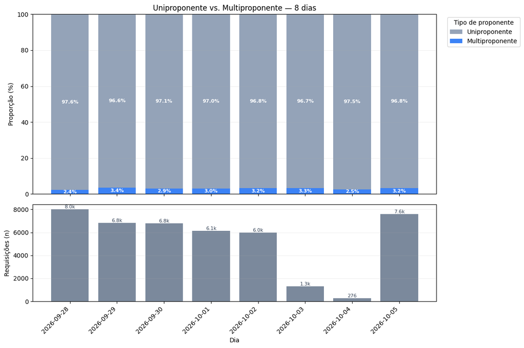

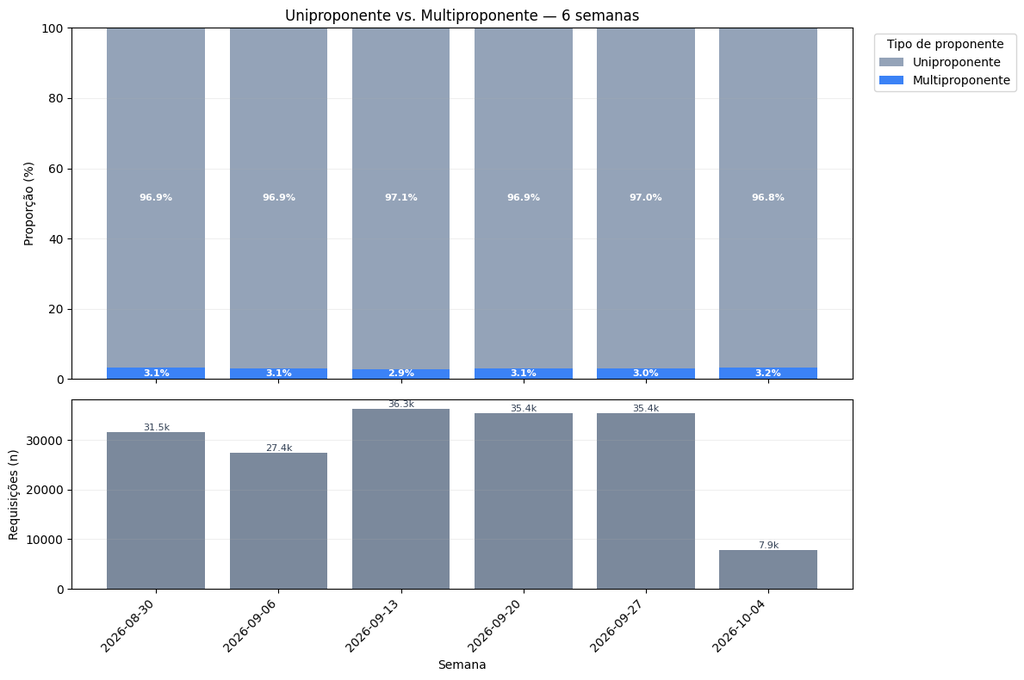

## Verificação de Cortes de Rating

Nesse caso, o que queremos é analisar se definição do Rating está sendo feita corretamente.

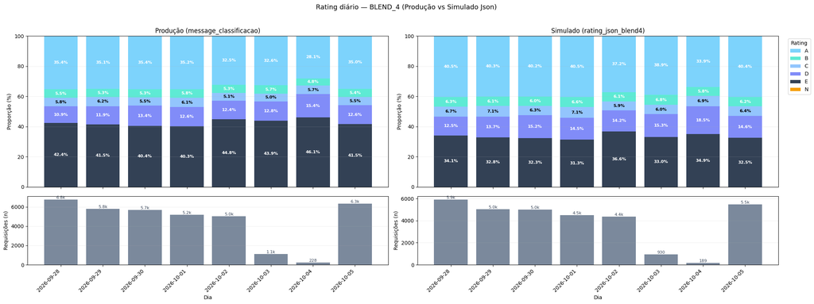

```
BLEND_4
```

| rating_json_blend4 message_classificacao | A | B | C | D | E | All |
| --- | --- | --- | --- | --- | --- | --- |
| A | 12525 | 0 | 0 | 0 | 0 | 12525 |
| B | 0 | 1952 | 0 | 0 | 0 | 1952 |
| C | 0 | 0 | 2058 | 0 | 0 | 2058 |
| D | 0 | 0 | 0 | 4433 | 0 | 4433 |
| E | 0 | 0 | 0 | 0 | 10445 | 10445 |
| All | 12525 | 1952 | 2058 | 4433 | 10445 | 31413 |

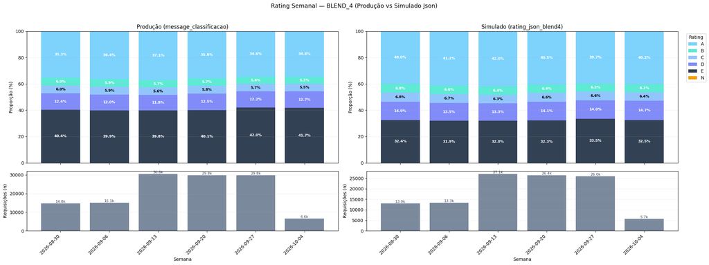

```
BLEND_4
```

| rating_json_blend4 message_classificacao | A | B | C | D | E | All |
| --- | --- | --- | --- | --- | --- | --- |
| A | 45336 | 0 | 0 | 0 | 0 | 45336 |
| B | 0 | 7172 | 0 | 0 | 0 | 7172 |
| C | 0 | 0 | 7285 | 0 | 0 | 7285 |
| D | 0 | 0 | 0 | 15406 | 0 | 15406 |
| E | 0 | 0 | 0 | 0 | 36198 | 36198 |
| All | 45336 | 7172 | 7285 | 15406 | 36198 | 111397 |

# Salvar HTML